# 7. Network Flow II

Algorithm II

7. Network Flow II

WU Xiaokun 吴晓堃

xkun.wu [at] gmail

## Max-flow and min-cut applications

**Max-flow and min-cut problems are widely applicable model**.

- Data mining.
- Open-pit mining.
- Bipartite matching.
- Network reliability.
- Baseball elimination.
- Image segmentation.
- Network connectivity.
- Markov random fields.
- Distributed computing.
- Security of statistical data.
- Egalitarian stable matching.
- Network intrusion detection.
- Multi-camera scene reconstruction.
- Sensor placement for homeland security.
- Many, many, more.

# Bipartite matching

## Max matching

**Def**. Given an undirected graph $G = (V, E)$, subset of edges $M \subseteq E$ is a **matching** if each node appears in at most one edge in $M$.

**Max matching**. Given a graph $G$, find a max-cardinality matching.

## Bipartite matching

**Def**. A graph $G$ is **bipartite** if the nodes can be partitioned into two subsets $L$ and $R$ such that every edge connects a node in $L$ with a node in $R$.

**Bipartite matching**. Given a bipartite graph $G = (L \cup R, E)$, find a max-cardinality matching.

## Bipartite matching: max-flow formulation

**Formulation**.

- Create digraph $G' = (L \cup R \cup \{s, t\}, E')$.
- Direct all edges from $L$ to $R$, and assign infinite (or unit) capacity.
- Add unit-capacity edges from $s$ to each node in $L$.
- Add unit-capacity edges from each node in $R$ to $t$.

## Max-flow formulation: correctness

**Theorem**. 1-1 correspondence between matchings of cardinality $k$ in $G$ and integral flows of value $k$ in $G'$.  
**Pf**. $\Rightarrow$

- Let $M$ be a matching in $G$ of cardinality $k$.
- Consider flow $f$ that sends 1 unit on each of the $k$ corresponding paths.
- $f$ is a flow of value $k$.

## Max-flow formulation: correctness (cont.)

**Theorem**. 1-1 correspondence between matchings of cardinality $k$ in $G$ and integral flows of value $k$ in $G'$.  
**Pf**. $\Leftarrow$

- Let $f$ be an integral flow in $G'$ of value $k$.
- Consider $M$ = set of edges from $L$ to $R$ with $f(e) = 1$.
  - each node in $L$ and $R$ participates in at most one edge in $M$
  - $|M| = k$: cut $(L \cup \{s\}, R \cup \{t\})$ has $k$ leaving and 0 entering

## Max-flow for bipartite matching

**Theorem**. 1-1 correspondence between matchings of cardinality $k$ in $G$ and integral flows of value $k$ in $G'$.

**Corollary**. Can solve bipartite matching problem via max-flow formulation.  
**Pf**.

- Integrality theorem $\Rightarrow$ there exists a max flow $f^\ast$ in $G'$ that is integral.
- 1-1 correspondence $\Rightarrow f^\ast$ corresponds to max-cardinality matching.

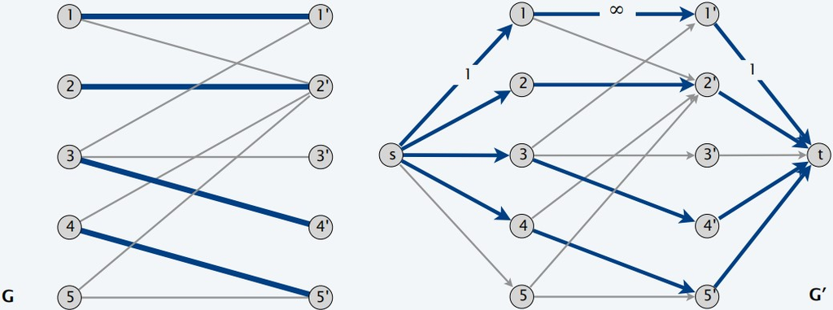

## Quiz: bipartite graph via Ford-Fulkerson

What is running time of Ford-Fulkerson algorithms to find a max-cardinality matching in a bipartite graph with $|L| = |R| = n$?

**A**. $O(m + n)$  
**B**. $O(mn)$  
**C**. $O(mn^2)$  
**D**. $O(m^2n)$

B. $O(m n C)$ and $C$ is a constant now.

## Perfect matchings

**Def**. Given a graph $G = (V, E)$, a subset of edges $M \subseteq E$ is a **perfect matching** if each node appears in exactly one edge in $M$.

**Q**. When does a bipartite graph have a perfect matching?

**Structure of bipartite graphs with perfect matchings**.

- Clearly, we must have $|L| = |R| = n$.
- Which other conditions are necessary?
- Which other conditions are sufficient?

## Perfect matchings (cont.)

**Notation**. Let $S$ be a subset of nodes, and let $N(S)$ be the set of nodes adjacent to nodes in $S$.

**Observation**. If a bipartite graph $G = (L \cup R, E)$ has a perfect matching, then $|N(S)| \ge |S|$ for all subsets $S \subseteq L$.  
**Pf**. Each node in $S$ has to be matched to a different node in $N(S)$.

## Hall’s marriage theorem

**Theorem**. [Frobenius 1917, Hall 1935] Let $G = (L \cup R, E)$ be a bipartite graph with $|L| = |R|$. Then, graph $G$ has a perfect matching iff $|N(S)| \ge |S|$ for all subsets $S \subseteq L$.

**Pf**. $\Rightarrow$ This is the previous observation.

## Hall’s marriage theorem (cont.)

**Pf**. $\Leftarrow$ Suppose $G$ does not have a perfect matching.

- Formulate as a max-flow problem and let $(A, B)$ be a min cut in $G'$.
  - By max-flow min-cut theorem, $cap(A, B) < |L|$.
- Define $L_A = L \cap A, L_B = L \cap B, R_A = R \cap A$.
  - $cap(A, B) = |L_B| + |R_A| \Rightarrow |R_A| < |L| - |L_B| = |L_A|$.
  - Min-cut can’t use $\infty$ edges $\Rightarrow N(L_A) \subseteq R_A$.
    - $|N(L_A)| \le |R_A| < |L_A|$.
- Choose $S = L_A$, contrapositive.

$L_A = \{2, 4, 5\}$  
$L_B = \{1, 3\}$  
$R_A = \{2', 5'\}$  
$N(L_A) = \{2', 5'\}$

# Disjoint paths

## Edge-disjoint paths

**Def**. Two paths are **edge-disjoint** if they have no edge in common.

**Edge-disjoint paths problem**. Given a digraph $G = (V, E)$ and two nodes $s$ and $t$, find the max number of edge-disjoint $s \leadsto t$ paths.

**Ex**. Communication networks.

## Edge-disjoint: Max-flow

**Max-flow formulation**. Assign unit capacity to every edge.

**Theorem**. 1-1 correspondence between $k$ edge-disjoint $s \leadsto t$ paths in $G$ and integral flows of value $k$ in $G'$.  
**Pf**. $\Rightarrow$ Let $P_1, \ldots, P_k$ be $k$ edge-disjoint $s \leadsto t$ paths in $G$.

- Set $f(e) = 1:\ \text{edge}\ e\ \text{participates in some path}$; $0:\ \text{otherwise}$.
- Since paths are edge-disjoint, $f$ is a flow of value $k$.

## Edge-disjoint: Max-flow (cont.)

**Max-flow formulation**. Assign unit capacity to every edge.

**Theorem**. 1-1 correspondence between $k$ edge-disjoint $s \leadsto t$ paths in $G$ and integral flows of value $k$ in $G'$.  
**Pf**. $\Leftarrow$ Let $f$ be an integral flow in $G'$ of value $k$.

- Consider edge $(s, u)$ with $f(s, u) = 1$.
  - by flow conservation, there exists an edge $(u, v)$ with $f(u, v) = 1$
  - continue until reach $t$, always choosing a new edge
- Produces $k$ (not necessarily simple) edge-disjoint paths.

## Edge-disjoint: Max-flow solution

**Max-flow formulation**. Assign unit capacity to every edge.

**Theorem**. 1-1 correspondence between $k$ edge-disjoint $s \leadsto t$ paths in $G$ and integral flows of value $k$ in $G'$.

**Corollary**. Can solve edge-disjoint paths problem via max-flow formulation.  
**Pf**.

- Integrality theorem $\Rightarrow$ there exists a max flow $f^\ast$ in $G'$ that is integral.
- 1-1 correspondence $\Rightarrow f^\ast$ corresponds to max number of edge-disjoint $s \leadsto t$ paths in $G$.

## Network connectivity

**Def**. A set of edges $F \subseteq E$ **disconnects** $t$ from $s$ if every $s \leadsto t$ path uses at least one edge in $F$.

**Network connectivity**. Given a digraph $G = (V, E)$ and two nodes $s$ and $t$, find min number of edges whose removal disconnects $t$ from $s$.

## Menger’s theorem

Theorem. [Menger 1927] The max number of edge-disjoint $s \leadsto t$ paths equals the min number of edges whose removal disconnects $t$ from $s$.  
**Pf**. $\le$

- Suppose the removal of $F \subseteq E$ disconnects $t$ from $s$, and $|F| = k$.
- Every $s \leadsto t$ path uses at least one edge in $F$.
- Hence, the number of edge-disjoint paths is $\le k$.

## Menger’s theorem (cont.)

Theorem. [Menger 1927] The max number of edge-disjoint $s \leadsto t$ paths equals the min number of edges whose removal disconnects $t$ from $s$.  
**Pf**. $\ge$

- Suppose max number of edge-disjoint $s \leadsto t$ paths is $k$.
- Then value of max flow = $k$.
- Max-flow min-cut theorem $\Rightarrow$ there exists a cut $(A, B)$ of capacity $k$.
- Let $F$ be set of edges going from $A$ to $B$.
- $|F| = k$ and disconnects $t$ from $s$.

## Quiz: edge-disjoint paths

How to find the max number of edge-disjoint paths in an undirected graph?

**A**. Solve the edge-disjoint paths problem in a digraph (by replacing each undirected edge with two antiparallel edges).  
**B**. Solve a max flow problem in an undirected graph.  
**C**. Both A and B.  
**D**. Neither A nor B.

C. both are fine.

## Edge-disjoint: undirected graphs

**Def**. Two paths are **edge-disjoint** if they have no edge in common.

**Edge-disjoint paths problem in undirected graphs**. Given a graph $G = (V, E)$ and two nodes $s$ and $t$, find the max number of edge-disjoint $s-t$ paths.

## Undirected Edge-disjoint: Max-flow

**Max-flow formulation**. Replace each edge with two antiparallel edges and assign unit capacity to every edge.

**Observation**. Two paths $P_1$ and $P_2$ may be edge-disjoint in the digraph but not edge-disjoint in the undirected graph.

- if $P_1$ uses edge $(u, v)$ and $P_2$ uses its antiparallel edge $(v, u)$

## Undirected Menger’s theorem

**Lemma**. In any flow network, there exists a maximum flow $f$ in which for each pair of antiparallel edges $e$ and $e'$: either $f(e) = 0$ or $f(e') = 0$ or both. Moreover, integrality theorem still holds.  
**Pf**. [ by induction on number of such pairs ]

- Suppose $f(e) > 0$ and $f(e') > 0$ for a pair of antiparallel edges $e$ and $e'$.
- Set $f(e) = f(e) - \delta$ and $f(e') = f(e') - \delta$, where $\delta = \min \{ f(e), f(e') \}$.
  - they cancel each other
- $f$ is still a flow of the same value but has one fewer such pair.

## Undirected Menger’s theorem (cont.)

**Max-flow formulation**. Replace each edge with two antiparallel edges and assign unit capacity to every edge.

**Lemma**. In any flow network, there exists a maximum flow $f$ in which for each pair of antiparallel edges $e$ and $e'$: either $f(e) = 0$ or $f(e') = 0$ or both. Moreover, integrality theorem still holds.

**Theorem**. Max number of edge-disjoint $s \leadsto t$ paths = value of max flow.  
**Pf**. Similar to proof in digraphs; use lemma.

## More Menger theorems

**Theorem**. Given an *undirected* graph and two nodes $s$ and $t$, the max number of *edge-disjoint* s-t paths equals the min number of edges whose removal disconnects $s$ and $t$.

**Theorem**. Given an *undirected* graph and two nonadjacent nodes $s$ and $t$, the max number of internally *node-disjoint* s-t paths equals the min number of internal nodes whose removal disconnects $s$ and $t$.

**Theorem**. Given a *directed* graph with two nonadjacent nodes $s$ and $t$, the max number of internally *node-disjoint* $s \leadsto t$ paths equals the min number of internal nodes whose removal disconnects $t$ from $s$.

# Extensions to max flow

## Quiz: Extensions to max flow

Which extensions to max flow can be easily modeled?

**A**. Multiple sources and multiple sinks.  
**B**. Undirected graphs.  
**C**. Lower bounds on edge flows.  
**D**. All of the above.

## Multiple sources & sinks

**Def**. Given a digraph $G = (V, E)$ with edge capacities $c(e) \ge 0$ and multiple source nodes and multiple sink nodes, find max flow that can be sent from the source nodes to the sink nodes.

**Max-flow formulation**.

- Add a new source node $s$ and sink node $t$.
- For each original source node $s_i$ add edge $(s, s_i)$ with capacity $\infty$.
- For each original sink node $t_i$, add edge $(t_i, t)$ with capacity $\infty$.

**Claim**. 1-1 correspondence between flows in $G$ and $G'$.

## Circulation w/ supplies & demands

**Def**. Given a digraph $G = (V, E)$ with edge capacities $c(e) \ge 0$ and node demands $d(v)$, a **circulation** is a function $f(e)$ that satisfies:

- [capacity] For each $e \in E: 0 \le f(e) \le c(e)$
- [conservation] For each $v \in V: \sum_{e\ \text{into}\ v} f(e) - \sum_{e\ \text{out}\ v} f(e) = d(v)$

**Max-flow formulation**.

- Add new source $s$ and sink $t$.
- For each $v$ with $d(v) < 0$, add edge $(s, v)$ with capacity $-d(v)$.
- For each $v$ with $d(v) > 0$, add edge $(v, t)$ with capacity $d(v)$.

**Claim**. $G$ has circulation iff $G'$ has max flow of value $D = \sum_{v: d(v) > 0} d(v) = \sum_{v: d(v) < 0} -d(v)$

- ie., saturates all edges leaving $s$ and entering $t$

## Circulation w/ S & D

**Integrality theorem**. If all capacities and demands are integers, and there exists a circulation, then there exists one that is integer-valued.  
**Pf**. Follows from max-flow formulation + integrality theorem for max flow.

**Theorem**. Given $(V, E, c, d)$, there does *not* exist a circulation iff there exists a node partition $(A, B)$ such that $\sum_{v \in B} d(v) > cap(A, B)$.

- ie., demand by nodes in $B$ exceeds supply of nodes in $B$ plus max capacity of edges going from $A$ to $B$

**Pf sketch**. Look at min cut in $G'$.

## Circulation w/ S & D & lower bounds

**Def**. Given a digraph $G = (V, E)$ with edge capacities $c(e) \ge 0$, lower bounds $l(e) \ge 0$, and node demands $d(v)$, a circulation $f(e)$ is a function that satisfies:

- [capacity] For each $e \in E: l(e) \le f(e) \le c(e)$
- [conservation] For each $v \in V: \sum_{e\ \text{into}\ v} f(e) - \sum_{e\ \text{out}\ v} f(e) = d(v)$

**Circulation problem with lower bounds**. Given $(V, E, l, c, d)$, does there exist a feasible circulation?

## Circulation w/ S & D & LB

**Max-flow formulation**. Model lower bounds as circulation with demands.

- Send $l(e)$ units of flow along edge $e$.
- Update demands of both endpoints.

**Theorem**. There exists a circulation in $G$ iff there exists a circulation in $G'$. Moreover, if all demands, capacities, and lower bounds in $G$ are integers, then there exists a circulation in $G$ that is integer-valued.  
**Pf sketch**. $f(e)$ is a circulation in $G$ iff $f'(e) = f(e) - l(e)$ is a circulation in $G'$.

# Survey design

## Survey Design Problem

**Goal**. Design a survey that meets following specs, if possible.

- Design survey asking $n_1$ consumers about $n_2$ products.
- Can survey consumer $i$ about product $j$ only if they own it.
- Ask consumer $i$ between $c_i$ and $c_i'$ questions.
- Ask between $p_j$ and $p_j'$ consumers about product $j$.

**Bipartite perfect matching**. Special case when $c_i = c_i' = p_j = p_j' = 1$.

## Survey Design: Max-flow

**Max-flow formulation**. Model as a circulation problem with lower bounds.

- Add edge $(i, j)$ if consumer $j$ owns product $i$.
- Add edge from $s$ to consumer $j$.
- Add edge from product $i$ to $t$.
- Add edge from $t$ to $s$.
- All demands = 0.
- Integer circulation $\Leftrightarrow$ feasible survey design.

# Airline scheduling

## Airline Scheduling Problem

**Airline scheduling**.

- Complex computational problem faced by airline carriers.
- Must produce schedules that are efficient in terms of equipment usage, crew allocation, and customer satisfaction.
  - even in presence of unpredictable events, such as weather and breakdowns
- One of largest consumers of high-powered algorithmic techniques.

**“Toy problem”**.

- Manage flight crews by reusing them over multiple flights.
- Input: set of $k$ flights for a given day.
- Flight $i$ leaves origin $o_i$ at time $s_i$ and arrives at destination $d_i$ at time $f_i$.
- Minimize number of flight crews.

## Airline Scheduling: Circulation

**Circulation formulation**. [to see if $c$ crews suffice]

- For each flight $i$, include two nodes $u_i$ and $v_i$.
- Add source $s$ with demand $-c$, and edges $(s, u_i)$ with capacity 1.
- Add sink $t$ with demand $c$, and edges $(v_i, t)$ with capacity 1.
- For each $i$, add edge $(u_i, v_i)$ with lower bound and capacity 1.
- if flight $j$ reachable from $i$, add edge $(v_i, uj)$ with capacity 1.

## Airline Scheduling: analysis

**Theorem**. The airline scheduling problem can be solved in $O(k^3 \log k)$ time.  
**Pf**.

- $k$ = number of flights.
- $c$ = number of crews (unknown).
- $O(k)$ nodes, $O(k^2)$ edges.
- At most $k$ crews needed.
  - $\Rightarrow$ solve $log_2 k$ circulation problems.
    - binary search for min value $c^\ast$
- Value of any flow is between $0$ and $k$.
  - $\Rightarrow$ at most $k$ augmentations per circulation problem.
- Overall time = $O(k^3 \log k)$.

**Remark**. Can solve in $O(k^3)$ time by formulating as *minimum-flow* problem.

## Airline Scheduling: practical discussion

**Remark**. We solved a toy version of a real problem.

**Real-world problem models countless other factors**:

- Union regulations: e.g., flight crews can fly only a certain number of hours in a given time window.
- Need optimal schedule over planning horizon, not just one day.
- Approaching deadhead has a cost.
- Flights don’t always leave or arrive on schedule.
- Simultaneously optimize both flight schedule and fare structure.

**Message**.

- Our solution is a generally useful technique for efficient reuse of limited resources but trivializes real airline scheduling problem.
- Flow techniques useful for solving airline scheduling problems (and are widely used in practice).
- Running an airline efficiently is a very difficult problem.

# Image segmentation

## Image Segmentation Problem

**Image segmentation**.

- Divide image into coherent regions.
- Central problem in image processing.

**Ex**. Separate human from background and reconstruct a new scene.

## FG/BG segmentation

**Foreground / background segmentation**.

- Label each pixel as belonging to foreground or background.
- $V$ = set of pixels, $E$ = pairs of neighboring pixels.
  - $a_i \ge 0$ is likelihood pixel $i$ in foreground.
  - $b_j \ge 0$ is likelihood pixel $i$ in background.
  - $p_{ij} \ge 0$ is separation penalty for labeling one of neighboring $i$ and $j$ as foreground, and the other as background.

## FG/BG segmentation: goals

- Accuracy: if $a_i > b_j$ in isolation, prefer to label $i$ in foreground.
- Smoothness: if many neighbors of $i$ are labeled foreground, we should be inclined to label $i$ as foreground.
- Find partition $(A, B)$ that maximizes:

$$\sum_{i \in A} a_i + \sum_{j \in B} b_j - \sum_{(i,j) \in E, |A \cap
\{i,j\}| = 1} p_{ij}$$

## FG/BG segmentation: min-cut?

**Formulate as min-cut problem**. Issues:

- Maximization.
- No source or sink.
- Undirected graph

**Turn into minimization problem**.

- Maximizing: $\sum_{i \in A} a_i + \sum_{j \in B} b_j - \sum_{(i,j) \in E, |A \cap \{i,j\}| = 1} p_{ij}$
  - is equivalent to minimizing: $(\sum_{i \in V} a_i + \sum_{j \in V} b_j) - (\sum_{i \in A} a_i + \sum_{j \in B} b_j - \sum_{(i,j) \in E, |A \cap \{i,j\}| = 1} p_{ij})$
  - or alternatively:

$$\sum_{j \in B} a_j + \sum_{i \in A} b_i + \sum_{(i,j) \in E, |A \cap
\{i,j\}| = 1} p_{ij}$$

## FG/BG segmentation: min-cut

**Formulate as min-cut problem $G' = (V' , E')$**.

- Include node for each pixel.
- Use two antiparallel edges instead of undirected edge.
- Add source $s$ to correspond to foreground.
- Add sink $t$ to correspond to background.

## FG/BG segmentation: min-cut (cont.)

Consider min-cut $(A, B)$ in $G'$.

- $A$ = foreground.

$$cap(A,B) = \sum_{j \in B} a_j + \sum_{i \in A} b_i + \sum_{(i,j) \in E,
i \in A, j \in B} p_{ij}$$

- Precisely the quantity we want to minimize.

## Grabcut image segmentation

**Grabcut**. [ Rother-Kolmogorov-Blake 2004 ]

- integrated in PowerPoint.

# Project selection

## Project Selection Problem

**Projects with prerequisites**.

- Set of possible projects $P$: project $v$ has associated revenue $p_v$.
  - value can be positive or negative
- Set of prerequisites $E$: $(v, w) \in E$ means $w$ is a prerequisite for $v$.
- A subset of projects $A \subseteq P$ is **feasible** if the prerequisite of every project in $A$ also belongs to $A$.

**Project selection problem**. Given a set of projects $P$ and prerequisites $E$, choose a feasible subset of projects to maximize revenue.

- aka. Maximum Weight Closure Problem

## Project selection: prerequisite graph

**Prerequisite graph**. Add edge $(v, w)$ if $w$ is a prerequisite for $v$.

## Project selection: min-cut

**Min-cut formulation**.

- Assign a capacity of $\infty$ to each prerequisite edge.
- Add edge $(s, v)$ with capacity $p_v$ if $p_v$ > 0.
- Add edge $(v, t)$ with capacity $-p_v$ if $p_v < 0$.
- For notational convenience, define $p_s = p_t = 0$.

## Project selection: min-cut (cont.)

**Claim**. $(A, B)$ is min-cut iff $A - \{ s \}$ is an optimal set of projects.

- Infinite capacity edges ensure $A - \{ s \}$ is feasible.
  - cut never cross $\infty$: prerequisite must go together.
- Max revenue because:
  - $cap(A,B) = \sum_{v \in B: p_v > 0} p_v + \sum_{v \in A: p_v < 0} (-p_v)$

## Open-pit mining

**Open-pit mining**. [studied since early 1960s]

- Blocks of earth are extracted from surface to retrieve ore.
- Each block $v$ has net value $p_v$ = value of ore - processing cost.
- Can’t remove block $v$ until both blocks $w$ and $x$ are removed.

# Tournament elimination

## Tournament: who is eliminated?

**Q**. Which teams have a chance of finishing the season with the most wins?

| T | W | L | P | A | B | C | D |
| --- | --- | --- | --- | --- | --- | --- | --- |
| A | 83 | 71 | 8 | - | 1 | 6 | 1 |
| B | 80 | 79 | 3 | 1 | - | 0 | 2 |
| C | 78 | 78 | 6 | 6 | 0 | - | 0 |
| D | 77 | 82 | 3 | 1 | 2 | 0 | - |

**D is mathematically eliminated**.

- D finishes with $\le 80$ wins.
- A already has $83$ wins.

**Remark**. This appear to be the only reasoning sports writers aware of.

## Tournament: who is eliminated?

**Q**. Which teams have a chance of finishing the season with the most wins?

| T | Win | Lose | to Play | A | B | C | D |
| --- | --- | --- | --- | --- | --- | --- | --- |
| A | 83 | 71 | 8 | - | 1 | 6 | 1 |
| B | 80 | 79 | 3 | 1 | - | 0 | 2 |
| C | 78 | 78 | 6 | 6 | 0 | - | 0 |
| D | 77 | 82 | 3 | 1 | 2 | 0 | - |

**B is mathematically eliminated**.

- B finishes with $\le 83$ wins.
- Either C or A will finish with $≥ 84$ wins.

**Observation**. Answer depends not only on how many games already won and left to play, but on whom they’re against.

## Tournament Elimination Problem

**Current standings**.

- Set of teams $S$.
- Distinguished team $z \in S$.
- Team $x$ has won $w_x$ games already.
- Teams $x$ and $y$ play each other $r_{xy}$ additional times.

**Tournament elimination problem**. Given the current standings, is there any outcome of the remaining games in which team $z$ finishes with the most (or tied for the most) wins?

- [Schwartz 1966] Possible winners in partially completed tournaments

## Tournament Elimination: max-flow

Can team 4 finish with most wins?

- Assume team 4 wins all remaining games $\Rightarrow w_4 + r_4$ wins.
- Arrange remaining games so that all teams have $\le w_4 + r_4$ wins.

## Tournament Elimination: max-flow (cont.)

**Theorem**. Team 4 not eliminated iff max flow saturates all edges leaving $s$.  
**Pf**.

- Integrality theorem $\Rightarrow$ each remaining game between $x$ and $y$ added to number of wins for team $x$ or team $y$.
- Capacity on $(x, t)$ edges ensure no team wins too many games.

## An explanation for sports writers

**Q**. Which teams have a chance of finishing the season with the most wins?

| T | Win | Lose | to Play | A | B | C | D | E |
| --- | --- | --- | --- | --- | --- | --- | --- | --- |
| A | 75 | 59 | 28 | - | 3 | 8 | 7 | 3 |
| B | 71 | 63 | 28 | 3 | - | 2 | 7 | 4 |
| C | 69 | 66 | 27 | 8 | 2 | - | 0 | 0 |
| D | 63 | 72 | 27 | 7 | 7 | 0 | - | 0 |
| E | 49 | 86 | 27 | 3 | 4 | 0 | 0 | - |

**E is mathematically eliminated**.

## Certificate of elimination

**Theorem**. [Hoffman-Rivlin 1967] Team $z$ is eliminated iff there exists a subset $T^\ast$: $w_z + g_z < \frac{w(T^\ast) + g(T^\ast)}{|T^\ast|}$.

- # wins: $w(T) = \sum_{i \in T} w_i$; # remaining: $g(T) = \sum_{\{x,y\} \subseteq T} g_{xy}$

**Pf**. $\Leftarrow$

- Suppose there exists $T^\ast ⊆ S$ satisfy certificate.
- Then, teams in $T^\ast$ win at least $(w(T^\ast) + g(T^\ast)) / |T^\ast|$ games on average.
- This exceeds maximum number that team $z$ can win.

## Certificate of elimination (cont.)

**Pf**. $\Rightarrow$

- Use max-flow formulation, and consider min cut $(A, B)$.
- Let $T^\ast$ = team nodes on source side $A$ of min cut.
- Observe that game node $x\text{-}y \in A$ iff both $x \in T^\ast$ and $y \in T^\ast$.
  - infinite capacity ensure $x\text{-}y \in A$, then both $x \in A$ and $y \in A$
  - if $x \in A$ and $y \in A$ but $x\text{-}y \notin A$, then adding $x\text{-}y$ to $A$ decreases the capacity of the cut by $g_{xy}$

## Certificate of elimination (cont.)

**Pf**. $\Rightarrow$

- Rearranging terms: $w_z + g_z < \frac{w(T^\ast) + g(T^\ast)}{|T^\ast|}$